# Question_No_6

Utsab Bhattarai

2024-05-31

# Do the followings in R studio using ggplot2 package with R script to knit PDF output:

## a. Create a dataset with following variables: age(10-99 years), sex(male/female), educational levels(No education/Primary/Secondary/Beyond secondary), socio-economic status(Low, Middle, High) and body mass index(14-38) with random 200 cases of each variable. Your roll number must be used to set the random seed.

```r
library(ggplot2)
library(dplyr)
library(tidyr)
set.seed(35)
data <- tibble(
  age = sample(10:99,
               size = 200,
               replace = TRUE),
  sex = sample(c("Male", "Female"),
               size = 200,
               replace = TRUE),
  educational_level = sample(c("No education", "Primary", "Secondary", "Beyond Secondary"),
                             size = 200,
                             replace = TRUE),
  socio_economic_status = sample(c("Low", "Middle", "High"),
                                 size = 200,
                                 replace = TRUE),
  body_mass_index = sample(14:38,
                           size = 200,
                           replace = TRUE)
)
```

## b. Create a scatterplot of age and body mass index variables using ggplot2 package and interpret the result carefully.

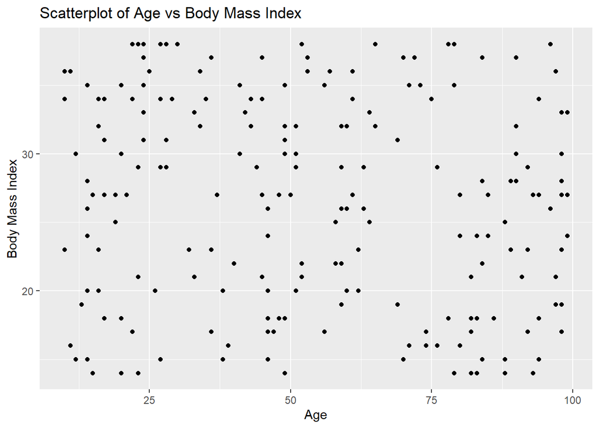

```r
ggplot(data, aes(x = age, y = body_mass_index)) +
  geom_point() +
  labs(title = "Scatterplot of Age vs Body Mass Index",
       x = "Age",
       y = "Body Mass Index")
```

Interpretation: The scatterplot shows the distribution of body mass index across different ages. There is no clear pattern or correlation observed between age and body mass index in this “data” dataset.

## c. Create classes of body mass index variable as : <18, 18-24, 25-30, 30+ and show it as pie chart using ggplot2 package and interpret it carefully.

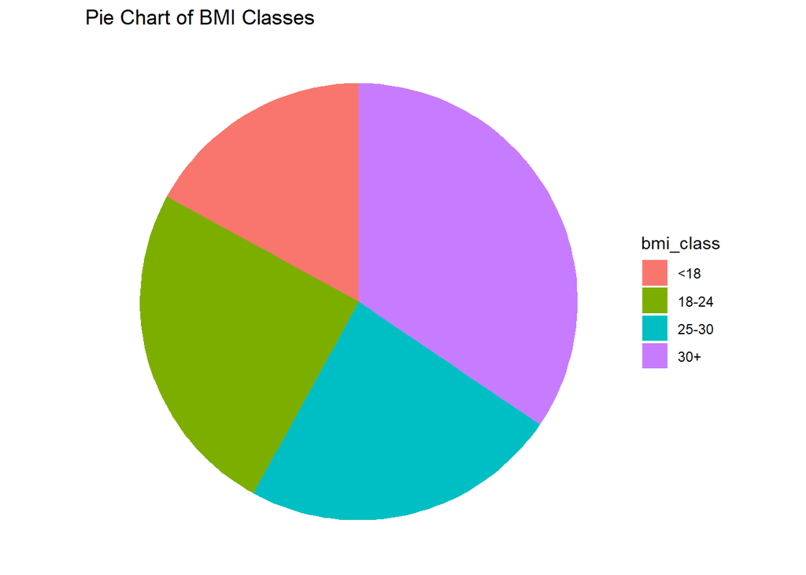

```r
data <- data %>%
  mutate(bmi_class = case_when(
    body_mass_index < 18 ~ "<18",
    body_mass_index >= 18 & body_mass_index <= 24 ~ "18-24",
    body_mass_index >= 25 & body_mass_index <= 30 ~ "25-30",
    body_mass_index > 30 ~ "30+"
  ))
bmi_class_counts <- data %>%
  count(bmi_class)
ggplot(bmi_class_counts,
       aes(x = "",
           y = n,
           fill = bmi_class)) +
  geom_bar(stat = "identity",
           width = 1) +
  coord_polar(theta = "y") +
  labs(title = "Pie Chart of BMI Classes") +
  theme_void()
```

## d. Create histogram of age variable with bin size of 15 using the ggplot2 package and interpret it carefully.

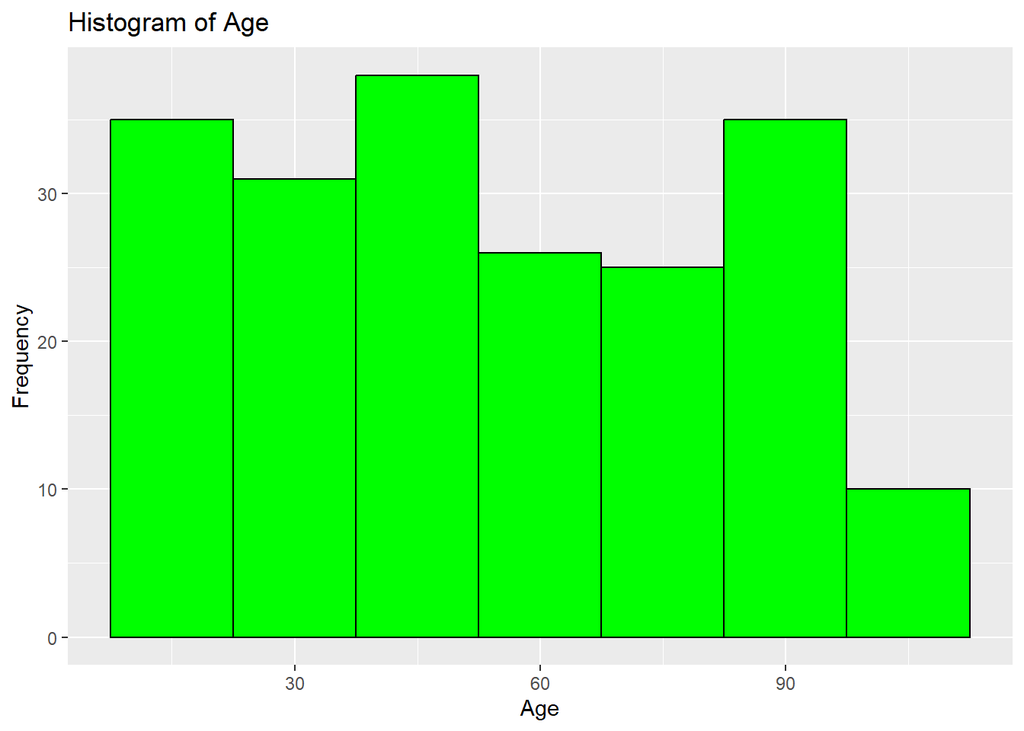

```r
ggplot(data, aes(x = age)) +
  geom_histogram(binwidth = 15, fill = "green", color = "black") +
  labs(title = "Histogram of Age",
       x = "Age",
       y = "Frequency")
```